# Ejemplo de Cálculo de la Reserva de Riesgos en Curso

Jose Alejandro Ramírez - Angie Llanos Culma - Cristian Gonzales Morales

2024-04-22

En este documento se presenta un ejemplo del cálculo de la reserva de riesgos en curso según el decreto 2555 de 2010, el decreto 2973 de 2013 y el decreto 1531 de 2022. Los datos utilizados corresponden a una muestra de 991 riesgos vigentes asociados a 250 contratos de seguro en el “Ramo de Automóviles” cuyos valores están en COP (datos anonimizados).

## Reserva de Prima No Devengada

La dimensión de la tabla de datos es:

```
## [1] 991   7
```

Se presentan las filas 113 a 120 de la tabla de datos:

| POLIZA_COBERTURA | PRIMA_COMERCIAL | DCTO_COMERCIAL | PRIMA_COMERCIAL_SIN_DCTO | FECHA_INICIO_VIG | FECHA_FIN_VIG | GASTOS_EXPEDICION |
| --- | --- | --- | --- | --- | --- | --- |
| 113 | 3692639 | 36000 | 3728639 | 2023-07-02 | 2024-07-02 | 20000 |
| 114 | 1641249 | 36000 | 1677249 | 2023-07-03 | 2024-07-03 | 20000 |
| 115 | 1620699 | 36000 | 1656699 | 2023-07-04 | 2024-07-04 | 20000 |
| 116 | 3010484 | 36000 | 3046484 | 2023-07-06 | 2024-07-06 | 20000 |
| 117 | 2269622 | 36000 | 2305622 | 2023-07-06 | 2024-07-06 | 20000 |
| 118 | 3946800 | 36000 | 3982800 | 2023-07-06 | 2024-07-06 | 20000 |
| 119 | 1279231 | 36000 | 1315231 | 2023-07-06 | 2024-07-06 | 20000 |
| 120 | 3860269 | 36000 | 3896269 | 2023-07-07 | 2024-07-07 | 20000 |

Los límites de la variable “Fecha inicio de vigencia” son:

```
## [1] "2023-01-01 UTC"
```

```
## [1] "2024-01-31 UTC"
```

Los límites de la variable “Fecha fin de vigencia” son:

```
## [1] "2024-01-01 UTC"
```

```
## [1] "2025-01-31 UTC"
```

La distribución de la variable “Prima Comercial” es:

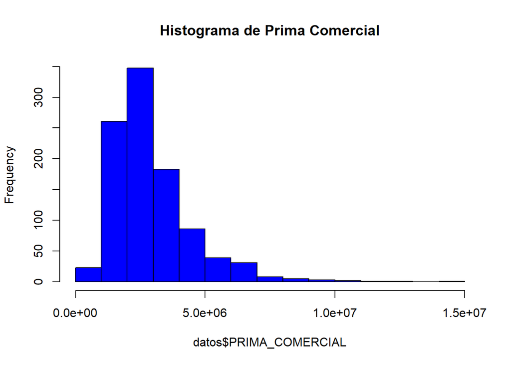

El valor total de la variable “Prima Comercial” es:

```r
currency(sum(datos$PRIMA_COMERCIAL))
```

```
## [1] $2,891,174,265.00
```

Se define la fecha de corte:

```
## [1] "2023-12-31 -05"
```

Se realiza el cálculo del máximo entre la prima comercial (prima emitida) y la prima comercial sin descuentos. Posteriormente se calcula la fracción de riesgo no corrido y la reserva de prima no devengada por amparo. Se presentan los cálculos para las filas 113 a 120 de la tabla de datos:

| POLIZA_COBERTURA | PRIMA_COMERCIAL | DCTO_COMERCIAL | PRIMA_COMERCIAL_SIN_DCTO | FECHA_INICIO_VIG | FECHA_FIN_VIG | GASTOS_EXPEDICION | resta_fechas_aprox | frac_riesgo_noc_def | RvaNoDev |
| --- | --- | --- | --- | --- | --- | --- | --- | --- | --- |
| 113 | 3692639 | 36000 | 3728639 | 2023-07-02 | 2024-07-02 | 20000 | 184 | 0.5027322 | 1864452.4 |
| 114 | 1641249 | 36000 | 1677249 | 2023-07-03 | 2024-07-03 | 20000 | 185 | 0.5054645 | 837680.5 |
| 115 | 1620699 | 36000 | 1656699 | 2023-07-04 | 2024-07-04 | 20000 | 186 | 0.5081967 | 831765.1 |
| 116 | 3010484 | 36000 | 3046484 | 2023-07-06 | 2024-07-06 | 20000 | 188 | 0.5136612 | 1554587.4 |
| 117 | 2269622 | 36000 | 2305622 | 2023-07-06 | 2024-07-06 | 20000 | 188 | 0.5136612 | 1174035.3 |
| 118 | 3946800 | 36000 | 3982800 | 2023-07-06 | 2024-07-06 | 20000 | 188 | 0.5136612 | 2035536.6 |
| 119 | 1279231 | 36000 | 1315231 | 2023-07-06 | 2024-07-06 | 20000 | 188 | 0.5136612 | 665309.9 |
| 120 | 3860269 | 36000 | 3896269 | 2023-07-07 | 2024-07-07 | 20000 | 189 | 0.5163934 | 2001679.9 |

Finalmente, el saldo se calcula como la sumatoria de la reserva de prima no devengada para todos los riesgos vigentes:

```r
RPND = sum(datos$RvaNoDev)
print(currency(RPND))
```

```
## [1] $1,902,095,015.96
```

## Reserva de Insuficiencia de Prima

Se presenta un informe mensualizado de ingresos y egresos del Ramo de Automóviles para una ventana de 2 años que corresponde a los periodos 2022 y 2023 respectivamente. Se muestran las últimos 6 filas de la tabla que corresponden a los ultimos meses del año 2023:

| PERIODO | PRIMA_DEVENGADA | INGRESOS_REASEGUROS | INGRESOS_FINANCIEROS | EGRESOS_SINIESTROS | EGRESOS_FINANCIEROS | EGRESOS_OTROS |
| --- | --- | --- | --- | --- | --- | --- |
| 2023-07-01 | 70016338 | 28006535 | 30807189 | 90181043 | 901810.4 | 5e+07 |
| 2023-08-01 | 90611472 | 36244589 | 39869048 | 116707576 | 1167075.8 | 5e+07 |
| 2023-09-01 | 97455415 | 38982166 | 42880383 | 125522575 | 1255225.8 | 5e+07 |
| 2023-10-01 | 100679516 | 40271806 | 44298987 | 129675217 | 1296752.2 | 8e+07 |
| 2023-11-01 | 123845107 | 49538043 | 54491847 | 159512497 | 1595125.0 | 8e+07 |
| 2023-12-01 | 130949045 | 52379618 | 57617580 | 168662370 | 1686623.7 | 8e+07 |

Se calculan los totales, tanto de ingresos como de egresos. Posteriormente se calculan las diferencias por mes así como el factor de insufuciencia. A continuación se presentan los calculos realizados para cada periodo:

| PERIODO | PRIMA_DEVENGADA | TOTAL_INGRESOS | TOTAL_EGRESOS | DIFERENCIA | DIFERENCIA_cumsum | PRIMA_DEVENGADA_cumsum | FACTOR |
| --- | --- | --- | --- | --- | --- | --- | --- |
| 2022-01-01 | 6343185 | 11671461 | 11251723 | -419738.0 | -419738 | 6343185 | 0.0000000 |
| 2022-02-01 | 50734664 | 93351782 | 95999710 | 2647928.0 | 2228190 | 57077849 | 0.0390377 |
| 2022-03-01 | 74742826 | 137526799 | 137231447 | -295352.2 | 1932838 | 131820675 | 0.0146626 |
| 2022-04-01 | 66714803 | 122755237 | 126787953 | 4032715.4 | 5965553 | 198535478 | 0.0300478 |
| 2022-05-01 | 64443667 | 118576348 | 123833478 | 5257130.1 | 11222683 | 262979145 | 0.0426752 |
| 2022-06-01 | 102568068 | 188725245 | 173428748 | -15296496.7 | -4073813 | 365547213 | 0.0000000 |
| 2022-07-01 | 84019606 | 154596074 | 149299425 | -5296649.8 | -9370463 | 449566819 | 0.0000000 |
| 2022-08-01 | 108733766 | 200070130 | 221449582 | 21379451.9 | 12008989 | 558300585 | 0.0215099 |
| 2022-09-01 | 116946498 | 215181557 | 232133361 | 16951803.7 | 28960792 | 675247083 | 0.0428892 |
| 2022-10-01 | 120815419 | 222300371 | 237166363 | 14865991.2 | 43826784 | 796062503 | 0.0550545 |
| 2022-11-01 | 148614128 | 273449996 | 273329147 | -120848.7 | 43705935 | 944676631 | 0.0462655 |
| 2022-12-01 | 157138854 | 289135491 | 284418792 | -4716698.8 | 38989236 | 1101815484 | 0.0353864 |
| 2023-01-01 | 5285988 | 9726217 | 11876436 | 2150218.3 | 41139454 | 1107101472 | 0.0371596 |
| 2023-02-01 | 42278887 | 77793151 | 99999758 | 22206606.6 | 63346061 | 1149380359 | 0.0551132 |
| 2023-03-01 | 62285688 | 114605666 | 126026206 | 11420539.8 | 74766601 | 1211666047 | 0.0617056 |
| 2023-04-01 | 55595669 | 102296031 | 117323294 | 15027262.8 | 89793864 | 1267261716 | 0.0708566 |
| 2023-05-01 | 53703056 | 98813623 | 114861232 | 16047608.4 | 105841472 | 1320964772 | 0.0801244 |
| 2023-06-01 | 85473390 | 157271037 | 156190623 | -1080413.9 | 104761058 | 1406438162 | 0.0744868 |
| 2023-07-01 | 70016338 | 128830062 | 141082854 | 12252791.9 | 117013850 | 1476454500 | 0.0792533 |
| 2023-08-01 | 90611472 | 166725108 | 167874652 | 1149543.2 | 118163393 | 1567065972 | 0.0754042 |
| 2023-09-01 | 97455415 | 179317964 | 176777801 | -2540163.6 | 115623230 | 1664521387 | 0.0694633 |
| 2023-10-01 | 100679516 | 185250309 | 210971969 | 25721659.3 | 141344889 | 1765200903 | 0.0800730 |
| 2023-11-01 | 123845107 | 227874996 | 241107622 | 13232626.1 | 154577515 | 1889046010 | 0.0818283 |
| 2023-12-01 | 130949045 | 240946242 | 250348993 | 9402751.0 | 163980266 | 2019995055 | 0.0811785 |

Finalmente, la reserva de insuficiencia de prima se calcula como el producto del factor de insuficiencia para una ventana de 2 años y el saldo de la reserva de prima no devengada:

```r
RIP = datos_rip$FACTOR[24]*RPND
print(currency(RIP))
```

```
## [1] $154,409,312.08
```